# Instructions

This is a digital school exam. The attached `.zip`-file contains all the material that you need to solve the problems. After unzipping this file, you will have the following directory structure:

```
ban400-h24
├── EXAM.R
├── backup
│   └── backup_data_question_f.RData
├── ban400-h24.Rproj
├── data
│   ├── ban400-h24-models.csv
│   ├── ban400-h24-turbines.csv
│   └── ban400-h24-wind.csv
└── notes
    ├── ban400-exam-notes.pdf
    ├── dplyr_cheat_sheet.pdf
    ├── ggplot2_cheat_sheet.pdf
    ├── lubridate_cheat_sheet.pdf
    ├── purrr_cheat_sheet.pdf
    └── tidyr_cheat_sheet.pdf
```

Open the `.Rproj`-file in RStudio. You can then write your solutions to the problems in the R-script `EXAM.R`, that has been initialized in the main folder. The folder `notes/` contains the cheat sheets and other notes as informed prior to the exam. Pay attention to the following provisions:

- **You will hand in the file `EXAM.R` when you are done. Do not modify any other file in the project folder.**
- Do not add, move or remove any file in the project folder.
- Use the `here`-package to refer to files in the project.
- You are not allowed to browse the internet during this exam.
- You are not allowed to use AI tools that are integrated in RStudio, such as Github Copilot.
- You are allowed to install new R-packages using `install.packages()`
- You can consult the documentation for functions and packages within RStudio:
  - Use `?function_name` to read the documentation for a function.
  - Use `?package_name` to read the documentation of a package that has been loaded with `library()`.
  - Use `??search_string` to search for a string within the base R documentation or the documentation of packages installed on your system.
- Write short comments throughout your solution. All answers that are not R-code should be written as comments (That is, using `#` at the beginning of the line).

Your answers will be assesed for correctess, efficiency, and readability, including consistent styling and proper commenting. Partial points can be awarded to partially correct solutions. If your code does not work as intended, it may help to write a short comment indicating what has gone wrong and how it could be fixed.

# Problems

In this exam, you will work with data from three wind farms operated by a company in Norway. The datasets provided contain information about wind turbines, including their unique IDs, locations, models, installation dates, and maximum production capacities. Additionally, you have access to wind speed observations recorded hourly over a three-month period at each wind farm. Your tasks involve loading and summarizing the turbine data, visualizing wind speed data, and creating a function to calculate the power output of turbines based on wind speed and turbine characteristics. You will also perform data manipulation and visualization to summarize power output across different turbines and locations. Finally, you will assess the potential impact of investing in new turbine technologies on power production.

**(a) Load and summarise the turbine data.**

The `.csv` file `ban400-h24-turbines.csv` contains data on all turbines in the data set, with the following variables:

- `turbine_id`: Uniqe ID number
- `location`: The location where the turbine is situated, one of three options: `Bremsund`, `Kappstad` or `Kvernes`
- `model`: The make and model of the turbine
- `installation_date:` The first day of operations for the turbine

You also have a small file `ban400-h24-models.csv` that contains information about the maximum production capacity of each of the turbine models in the turbines data. This table contains two variables:

- `model`: The make and model of the turbine
- `capacity`: The maximum production capacity of the turbine, in kilowatts (kW)

**Load the data into memory, and create a summary table with counts of the number of turbines of each model at each location. The table should also display the maximum production capacity of the turbines.**

```r
# Load all packages for all the questions here
library(tidyverse)
library(here)

turbines <- read_csv(here("data", "ban400-h24-turbines.csv"))
models   <- read_csv(here("data", "ban400-h24-models.csv"))

turbines %>%
  group_by(location, model) %>%
  summarise(n_turbines = n()) %>%
  full_join(models)
```

```
# A tibble: 9 × 4
# Groups:   location [3]
  location model   n_turbines capacity
  <chr>    <chr>        <int>    <dbl>
1 Bremsund AF-1500          6     1500
2 Bremsund SP-2500          7     2500
3 Bremsund V-2000           4     2000
4 Kappstad AF-1500         27     1500
5 Kappstad SP-2500         25     2500
6 Kappstad V-2000           5     2000
7 Kvernes  AF-1500         23     1500
8 Kvernes  SP-2500         15     2500
9 Kvernes  V-2000          18     2000
```

**(b) Load and visualize the wind data.**

The file `ban400-h24-wind.csv` contains hourly observations of mean wind at all three wind farms for the last three months of 2023. This table has three columns:

- `name`: The name of the location
- `time`: The timestamp of the observation in the format `dd.mm.YYYY HH:MM`
- `mean_wind`: The average wind at the location over the hour that *ends* at `time`

**Load this data into memory and create one line plot showing the three time series with different colors. Format the plot to make it publication ready.**

**Hint:** Remember to convert the `time` column to an appropriate variable type using, for example, a conversion function in the `lubridate` package.

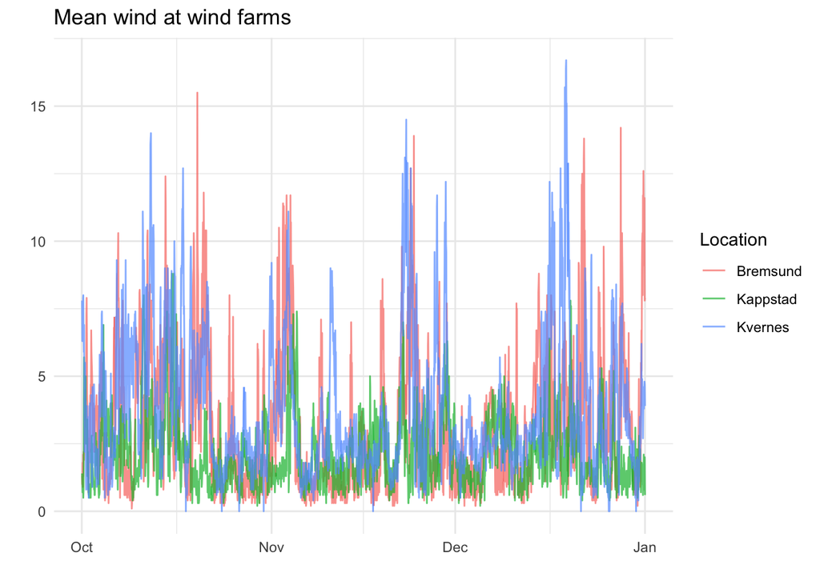

```r
wind <-
  read_csv(here("data", "ban400-h24-wind.csv")) %>%
  mutate(time = dmy_hm(time))

wind %>%
  ggplot(aes(x = time, y = mean_wind, colour = name)) +
  ylab("") +
  xlab("") +
  labs(colour = "Location") +
  ggtitle("Mean wind at wind farms") +
  geom_line(alpha = .7) +
  theme_minimal()
```

**(c) Add wind turbine parameters to the data.**

A wind turbine creates electric power according to the following rule: When the wind speed $W$ is less than a cut-in value $W_{\textrm{cut-in}}$, the turbine does not produce power at all. When the wind speed is between $W_{\textrm{cut-in}}$ and another value $W_{\textrm{rated}}$, it produces power roughly proportional to $W^3$. When the wind speed is between $W_{\textrm{rated}}$ and $W_{\textrm{cut-out}}$, the turbine produces power at its rated capacity, and when $W > W_{\textrm{cut-out}}$ the turbine needs to shut down to prevent damages due to mechanical stress, and the power production becomes zero.

```r
models <-
  models %>%
  mutate(cut_in = c(4, 4, 3),
         rated = c(13, 11.4, 10.8),
         cut_out = c(25, 25, 25))
```

**(d) Create power function.**

**Write a function that takes in a vector of wind speeds and returns the corresponding vector of output power. The additional parameters $P_{\textrm{rated}}$, $W_{\textrm{cut-in}}$, $W_{\textrm{rated}}$ and $W_{\textrm{cut-out}}$ can either be given as single numbers (in which case the power output will be calculated for the given set of turbine parameters) or vectors of the same length of the wind speed vector (in which case the power output will be calculated element-wise over the vector of wind speed and the parameter vectors). The function should include tests ensuring that the dimensions of the input conform with each other.**

**Hint:** Use the `stop()`-function to generate error messages.

```r
output <- function(W, P_rated, W_cutin, W_rated, W_cutout) {

  # Check wheter the input parameters are all of length one
  length_one <-
    (length(P_rated) == 1) & (length(W_cutin) == 1) &
    (length(W_rated) == 1) & (length(W_cutout) == 1)

  # Check whether the input parameters are of the same length as W
  equal_length <-
    (length(P_rated) == length(W)) & (length(W_cutin) == length(W)) &
    (length(W_rated) == length(W)) & (length(W_cutout) == length(W))

  # One of these must be true, otherwise generate error
  if(!(length_one | equal_length))
    stop("Turbine parameters must either all be scalars, or all be of the same length as W")

  # Initialize a vector of zeros
  ret <- 0 * W

  # It is convenient to create vectors out of the turbine parameters if they are
  # given as just single numbers:
  if(length_one){
    P_rated  <- rep(P_rated,  length(W))
    W_cutin  <- rep(W_cutin,  length(W))
    W_rated  <- rep(W_rated,  length(W))
    W_cutout <- rep(W_cutout, length(W))
  }

  # From here we can do a for-loop that would look like this:
  # for(i in 1:length(W)) {
  #   if((W[i] >= W_cutin[i]) & (W[i] < W_rated[i])) {
  #     ret[i] <- (P_rated[i] * ((W[i] - W_cutin[i])/(W_rated[i] - W_cutin[i]))^3)
  #   } else if((W[i] >= W_rated[i]) & (W[i] < W_cutout[i])) {
  #     ret[i] <- P_rated[i]
  #   }
  # }

  # It is much more efficient, however, to use vectorized code directly.

  # Which position of the vector corresponds to wind speeds between W_cutin and
  # W_rated? This works the same way with vector or scalar parameters
  where_cutin <- (W >= W_cutin) & (W < W_rated)
  where_rated <- (W >= W_rated) & (W < W_cutout)

  ret[where_cutin] <- (P_rated * ((W - W_cutin)/(W_rated - W_cutin))^3)[where_cutin]
  ret[where_rated] <- P_rated[where_rated]

  # Return the result
  return(ret)
}
```

**(e) Plot the power curve(s).**

Define a suitable vector of wind speeds ranging from 0 m/s to 30 m/s and choose *one* of the following tasks:

Either:

1. **Plot the output power as a function of wind speed for *one* of the turbine models in our data set.**

Or:

2. **Plot the output power for *all* of the turbine models in our data set as a function of wind speed.**

In either case, the plot must be labelled appropriately.

(Task 1 gives a maximum of 50% of the points on this question. In order to get full score on task 2 you must use a more efficient technique than essentially doing task 1 three times with different parameters)

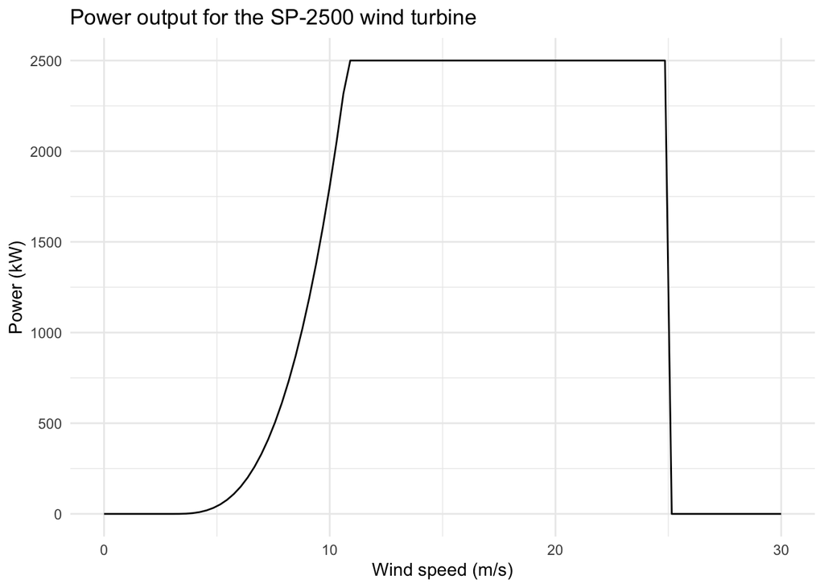

```r
# Task 1:
tibble(wind_speed = seq(0, 30, length.out = 100)) %>%
  mutate(power = output(wind_speed, P_rated = 2500, W_cutin = 3, W_rated = 10.8,
                        W_cutout = 25)) %>%
  ggplot(aes(x = wind_speed, y = power)) +
  geom_line() +
  xlab("Wind speed (m/s)") +
  ylab("Power (kW)") +
  ggtitle("Power output for the SP-2500 wind turbine") +
  theme_minimal()
```

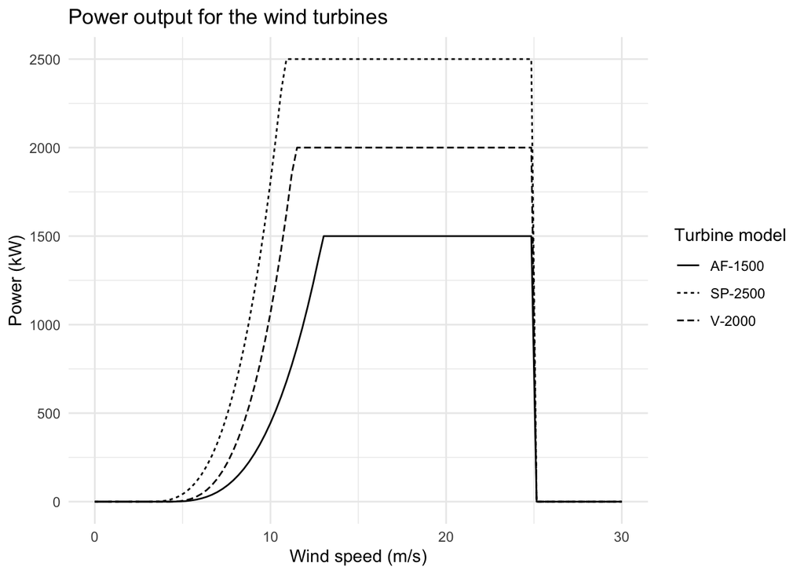

```r
# Task 2:
models %>%
  mutate(wind_speed = list(seq(0, 30, length.out = 100))) %>%
  unnest(wind_speed) %>%
  mutate(power = output(wind_speed, capacity, cut_in, rated, cut_out)) %>%
  ggplot(aes(x = wind_speed, y = power, linetype = model)) +
  geom_line() +
  xlab("Wind speed (m/s)") +
  ylab("Power (kW)") +
  labs(linetype = "Turbine model") +
  ggtitle("Power output for the wind turbines") +
  theme_minimal()
```

**(f) Calculate power output.**